# Time dependent AUC with survival data _ correct3

Hwang Seong-Yun

2022 4 15

# Loading packages

```r
library(survival)
library(timeROC)
library(timereg)
library(ggplot2)
library(reshape)
library(plyr)
library(tidyverse)
library(coxed)
library(gridExtra)
```

# Generating simulation data from Cox Regression Model

## Background

- reference 1 : https://doi.org/10.5351/KJAS.2018.31.6.761
- reference 2 : https://doi.org/10.1017/psrm.2018.19
- $h(t|x)=h_{0}(t)exp(f(x))$
- $H(t|x)=\int_{0}^{t} h(s|x)ds= \int_{0}^{t} h_{0}(s)exp(f(x))ds=H_{0}(t)exp(f(x))$
- $h(t|x)=\frac {f(t|x)}{S(t|x)}= -\frac {d}{dt} log[S(t|x)]$
- $log[S(t|x)]= -\int_{0}^{t} h(s|x)ds= -H(t|x)= -H_{0}(t)exp(f(x))$
- $S(t|x)=exp[-H_{0}(t)exp(f(x))]$
- In general,…
- $F(t|x)=1-exp[-H_{0}(t) exp(f(x))]$
- -> $F^{-1}(t|x)=H_{0}^{-1}[-log(1-t) exp(-f(x))]$
- By Inverse Transform Sampling, suppose that $U_{1}, U_{2} \overset{i.i.d}{\sim}\ U(0,1)$, then we can generate real survival time $Y$ from Cox Regression Model using this equation.
- $Y=H_{Y0}^{-1}[-log(U_{1})exp(-f(x))]$
- And by assuming non-informative censoring, we can generate censoring time $C$ like this equation. (Set $Y$ and $C$ are independent each other.)
- $C=H_{C0}^{-1}[-log(U_{2})]$
- And set censoring indicator $\delta=I(Y \leq C)$ and observed survival time $T=min(Y,C)$
- $H_{Y0}(t)$ : Basis cumulative hazard function of real survival time $Y$
- $H_{C0}(t)$ : Basis cumulative hazard function of censoring time $C$
- When parametric basis distribution of real survival time $Y$ and censoring time $C$ are Exponential distribution and independent each other, then ~
- $f_{0}(t)=\lambda e^{-\lambda t}, t>0$ -> $S_{0}(t)=e^{-\lambda t}$ -> $h_{0}(t)=\lambda$
- $\therefore Y=-\frac{1}{\lambda_{1}} log(U_{1}) exp(-f(x))$, $C=-\frac{1}{\lambda_{2}} log(U_{2})$

# Generating simulation data

## Assume linear relationship

```r
# Assume parametric basis distribution is Exponential distribution...
lambda1 <- 0.01 # parameter for generate Y
lambda2 <- 0.01 # parameter for generate C
beta1 <- 3 # true coefficients
Y <- c() # real survival time
C <- c() # censoring time
t <- c() # observed survival time
censor <- c() # censoring indicator
X <- c() # explanatory variable
U1 <- c() # random variable from U(0,1) for generate Y
U2 <- c() # random variable from U(0,1) for generate C
X2 <- c() # X^2

for (i in 1:1000) {
  U1[i] <- runif(1)
  U2[i] <- runif(1)
  # X[i] <- runif(1,min=0,max=10)
  X[i] <- rnorm(1,mean=0,sd=1)
  X2[i] <- X[i]^2
  Y[i] <- -(1/lambda1)*log(U1[i])*exp(-beta1*X[i])
  C[i] <- -(1/lambda2)*log(U2[i])
  t[i] <- min(Y[i],C[i])
  censor[i] <- ifelse(Y[i]<=C[i],1,0)
}

mean(1-censor) # censoring rate
```

```
## [1] 0.494
```

```r
dt1 <- data.frame(X=X, X2=X2, Y=Y, C=C, time=t, censor=censor)
head(dt1,20)
```

```
##             X         X2            Y          C        time censor
## 1   1.8983182 3.60361199 5.310628e-01  97.048863   0.5310628      1
## 2   1.5067782 2.27038062 3.284089e+00  25.166245   3.2840888      1
## 3  -0.6615190 0.43760742 1.897736e+02  89.449303  89.4493032      0
## 4   1.4592172 2.12931480 1.965999e+00  66.759797   1.9659992      1
## 5  -1.5599117 2.43332454 2.058087e+04  47.090236  47.0902361      0
## 6  -0.4258625 0.18135884 4.000767e+02  24.886245  24.8862454      0
## 7  -0.6834269 0.46707231 8.287011e+02  28.203643  28.2036435      0
## 8  -1.0358513 1.07298782 1.382580e+03  65.191125  65.1911255      0
## 9  -0.2108563 0.04446036 3.207359e+02 234.466580 234.4665799      0
## 10  0.8356313 0.69827959 9.705714e+00  44.277592   9.7057144      1
## 11 -0.2382184 0.05674799 6.498073e+02  63.451095  63.4510946      0
## 12 -0.3598913 0.12952174 1.264749e+02 108.230933 108.2309330      0
## 13  0.9579917 0.91774804 4.523480e+00  84.097886   4.5234799      1
## 14  0.1023342 0.01047230 8.472141e+01  35.905150  35.9051503      0
## 15  0.9222251 0.85049917 1.995384e+01   2.535876   2.5358760      0
## 16 -1.3841458 1.91585969 2.428849e+03 472.581809 472.5818093      0
## 17  0.3440577 0.11837571 1.102505e+01 362.755653  11.0250518      1
## 18  0.7586882 0.57560785 3.154306e+01   6.481987   6.4819874      0
## 19 -0.1559936 0.02433402 2.096713e+02  23.678834  23.6788341      0
## 20 -0.4365935 0.19061387 2.177174e+02 160.707091 160.7070905      0
```

```r
# dt1[c(order(dt1$time)),]$censor
```

### Time dependent AUC

### True model

- $h(t|x)=h _{0} (t)exp[f(x)]$
- $f(x)=\beta_{1} x$
- True coefficients : $\beta_{1}=3$

### Set linear model

- $h(t|x)=h _{0} (t)exp[f(x)]$
- $f(x)=\beta_{1}x$

```r
cox.lin.dt1 <- coxph(Surv(time,censor) ~ X, data=dt1)
summary(cox.lin.dt1)
```

```
## Call:
## coxph(formula = Surv(time, censor) ~ X, data = dt1)
##
##   n= 1000, number of events= 506
##
##      coef exp(coef) se(coef)     z Pr(>|z|)
## X  3.0654   21.4420   0.1041 29.44   <2e-16 ***
## ---
## Signif. codes:  0 '***' 0.001 '**' 0.01 '*' 0.05 '.' 0.1 ' ' 1
##
##   exp(coef) exp(-coef) lower .95 upper .95
## X     21.44    0.04664     17.48      26.3
##
## Concordance= 0.906  (se = 0.006 )
## Likelihood ratio test= 1418  on 1 df,   p=<2e-16
## Wald test            = 866.5  on 1 df,   p=<2e-16
## Score (logrank) test = 1057  on 1 df,   p=<2e-16
```

```r
risk.lin.dt1 <- predict(object=cox.lin.dt1, newdata=dt1, type="risk") # risk score
dt1$risk.lin.dt1 <- risk.lin.dt1
ROC.risk.lin.dt1 <- timeROC(T=dt1$time,
                         delta=dt1$censor,marker=dt1$risk.lin.dt1,
                         cause=1,weighting="marginal",
                         times=dt1$time)
ROC.risk.lin.dt1
```

```
## Time-dependent-Roc curve estimated using IPCW  (n=1000, without competing risks).
##                       Cases Survivors Censored AUC (%)
## t=0.00036077048764827     0       999        1      NA
## t=3.54824424288237      219       749       32   95.53
## t=20.3653541086743      363       500      137   95.72
## t=65.1911254580273      458       250      292   96.37
## t=472.581809319784      506         0      494      NA
##
## Method used for estimating IPCW:marginal
##
## Total computation time : 0.37  secs.
```

### Set quadratic model

- $h(t|x)=h _{0} (t)exp[f(x)]$
- $f(x)=\beta_{1}x+\beta_{2}x^2$

```r
cox.quad.dt1 <- coxph(Surv(time,censor) ~ X+X2, data=dt1)
summary(cox.quad.dt1)
```

```
## Call:
## coxph(formula = Surv(time, censor) ~ X + X2, data = dt1)
##
##   n= 1000, number of events= 506
##
##        coef exp(coef) se(coef)      z Pr(>|z|)
## X   3.10598  22.33109  0.14812 20.969   <2e-16 ***
## X2 -0.02804   0.97234  0.07173 -0.391    0.696
## ---
## Signif. codes:  0 '***' 0.001 '**' 0.01 '*' 0.05 '.' 0.1 ' ' 1
##
##    exp(coef) exp(-coef) lower .95 upper .95
## X    22.3311    0.04478   16.7042    29.853
## X2    0.9723    1.02844    0.8448     1.119
##
## Concordance= 0.906  (se = 0.006 )
## Likelihood ratio test= 1418  on 2 df,   p=<2e-16
## Wald test            = 856.7  on 2 df,   p=<2e-16
## Score (logrank) test = 1965  on 2 df,   p=<2e-16
```

```r
risk.quad.dt1 <- predict(object=cox.quad.dt1, newdata=dt1, type="risk") # risk score
dt1$risk.quad.dt1 <- risk.quad.dt1
ROC.risk.quad.dt1 <- timeROC(T=dt1$time,
                         delta=dt1$censor,marker=dt1$risk.quad.dt1,
                         cause=1,weighting="marginal",
                         times=dt1$time)
ROC.risk.quad.dt1
```

```
## Time-dependent-Roc curve estimated using IPCW  (n=1000, without competing risks).
##                       Cases Survivors Censored AUC (%)
## t=0.00036077048764827     0       999        1      NA
## t=3.54824424288237      219       749       32   95.53
## t=20.3653541086743      363       500      137   95.72
## t=65.1911254580273      458       250      292   96.37
## t=472.581809319784      506         0      494      NA
##
## Method used for estimating IPCW:marginal
##
## Total computation time : 0.62  secs.
```

#### Make AUC data

```r
# uncensored
uncensored.density1 <- density(dt1$time[dt1$censor==1])
data1_1 <- data.frame(time=uncensored.density1[["x"]],
                    density=uncensored.density1[["y"]])
data1_1$density.adjusted <- (max(na.omit(ROC.risk.lin.dt1[["AUC"]]))-min(na.omit(ROC.risk.lin.dt1[["AUC"]])))*(uncensored.density1[["y"]]-min(uncensored.density1[["y"]]))/(max(uncensored.density1[["y"]])-min(uncensored.density1[["y"]]))+min(na.omit(ROC.risk.lin.dt1[["AUC"]]))

# censored
censored.density1 <- density(dt1$time[dt1$censor==0])
data1_2 <- data.frame(time=censored.density1[["x"]],
                    density=censored.density1[["y"]])
data1_2$density.adjusted <- (max(na.omit(ROC.risk.lin.dt1[["AUC"]]))-min(na.omit(ROC.risk.lin.dt1[["AUC"]])))*(censored.density1[["y"]]-min(censored.density1[["y"]]))/(max(censored.density1[["y"]])-min(censored.density1[["y"]]))+min(na.omit(ROC.risk.lin.dt1[["AUC"]]))

res1 <- data.frame(time=ROC.risk.lin.dt1[["times"]],
                    cox.lin.dt1=ROC.risk.lin.dt1[["AUC"]],
                    cox.quad.dt1=ROC.risk.quad.dt1[["AUC"]])
res1 <- melt(data = res1,
                   id.vars = "time",
                   measure.vars = c("cox.lin.dt1","cox.quad.dt1"))
```

#### Time dependent AUC plot with ggplot2 (cox.lin.dt1, cox.quad.dt1)

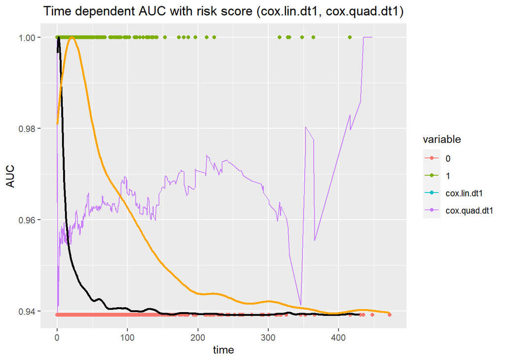

```r
dt1$censor1 <- ifelse(dt1$censor==1,
                    1,min(na.omit(ROC.risk.lin.dt1[["AUC"]])))
ggplot() +
  geom_line(data=res1, aes(x=time, y=value,
                            group=variable, color=variable)) +
  geom_point(data=dt1, aes(x=time, y=censor1, color=as.factor(censor))) +
  geom_line(data=data1_1, aes(x=time, y=density.adjusted),
            size=1, colour='black') +
  geom_line(data=data1_2, aes(x=time, y=density.adjusted),
            size=1, colour='orange') +
  scale_x_continuous(limits = c(min(dt1$time), max(dt1$time))) +
  ggtitle("Time dependent AUC with risk score (cox.lin.dt1, cox.quad.dt1)") +
  xlab("time") + ylab("AUC") +
  theme(plot.title = element_text(hjust = 0.5))
```

#### Mean value of Time dependent AUC (cox.lin.dt1, cox.quad.dt1)

```r
mean(ROC.risk.lin.dt1[["AUC"]],na.rm=TRUE)
```

```
## [1] 0.9598932
```

```r
mean(ROC.risk.quad.dt1[["AUC"]],na.rm=TRUE)
```

```
## [1] 0.9598932
```

#### Counting censored data

```r
dt1.censor <- dt1[dt1$censor==0,]
dt1.censor <- dt1.censor %>%
  mutate(n.cen=cut(dt1.censor$time,
                   breaks=seq(from=0,to=1000,by=50)))
table(dt1.censor$n.cen)
```

```
##
##      (0,50]    (50,100]   (100,150]   (150,200]   (200,250]   (250,300]
##         260         102          64          27          16           9
##   (300,350]   (350,400]   (400,450]   (450,500]   (500,550]   (550,600]
##           8           3           4           1           0           0
##   (600,650]   (650,700]   (700,750]   (750,800]   (800,850]   (850,900]
##           0           0           0           0           0           0
##   (900,950] (950,1e+03]
##           0           0
```

## Assume quadratic relationship

```r
# Assume parametric basis distribution is Exponential distribution...
lambda1 <- 0.01 # parameter for generate Y
lambda2 <- 0.01 # parameter for generate C
beta1 <- 3 ; beta2 <- 2 # true coefficients
Y <- c() # real survival time
C <- c() # censoring time
t <- c() # observed survival time
censor <- c() # censoring indicator
X <- c() # explanatory variable
U1 <- c() # random variable from U(0,1) for generate Y
U2 <- c() # random variable from U(0,1) for generate C
X2 <- c() # X^2

for (i in 1:1000) {
  U1[i] <- runif(1)
  U2[i] <- runif(1)
  # X[i] <- runif(1,min=0,max=10)
  X[i] <- rnorm(1,mean=0,sd=1)
  X2[i] <- X[i]^2
  Y[i] <- -(1/lambda1)*log(U1[i])*exp(-beta1*X[i]-beta2*X2[i])
  C[i] <- -(1/lambda2)*log(U2[i])
  t[i] <- min(Y[i],C[i])
  censor[i] <- ifelse(Y[i]<=C[i],1,0)
}

mean(1-censor) # censoring rate
```

```
## [1] 0.366
```

```r
dt2 <- data.frame(X=X, X2=X2, Y=Y, C=C, time=t, censor=censor)
head(dt2,20)
```

```
##             X         X2            Y          C         time censor
## 1  -0.6327607 0.40038606 1.315916e+02 182.289398 1.315916e+02      1
## 2   0.8310773 0.69068953 4.241756e-01 421.577799 4.241756e-01      1
## 3   0.3785454 0.14329661 2.383107e+00  49.398966 2.383107e+00      1
## 4   0.5806866 0.33719689 3.537601e+00 186.710851 3.537601e+00      1
## 5   0.2977108 0.08863172 1.291676e+01  18.677927 1.291676e+01      1
## 6   0.2705605 0.07320299 4.592988e+01  29.162494 2.916249e+01      0
## 7   2.5509053 6.50711783 2.620051e-09  55.650999 2.620051e-09      1
## 8  -0.8714905 0.75949564 7.517004e+01  76.459891 7.517004e+01      1
## 9  -1.2175594 1.48245099 1.774995e+02 180.622024 1.774995e+02      1
## 10 -0.9133495 0.83420739 6.644035e+01  55.886990 5.588699e+01      0
## 11  1.2210020 1.49084587 1.502984e-02  22.263731 1.502984e-02      1
## 12 -0.9343312 0.87297481 5.142712e+01 162.778708 5.142712e+01      1
## 13  0.7477284 0.55909783 1.526996e+00  79.536980 1.526996e+00      1
## 14  1.2726189 1.61955893 1.056463e-02 211.809420 1.056463e-02      1
## 15 -1.5642633 2.44691980 8.007983e+01   2.492155 2.492155e+00      0
## 16  1.1262014 1.26832968 1.566887e-01  38.178964 1.566887e-01      1
## 17  0.3324327 0.11051153 1.191453e+00 135.817643 1.191453e+00      1
## 18  0.2749720 0.07560958 2.166195e+01 110.518631 2.166195e+01      1
## 19 -0.3075319 0.09457586 1.585125e+01  95.711485 1.585125e+01      1
## 20  1.0082653 1.01659898 2.892084e-02 487.602927 2.892084e-02      1
```

```r
# dt2[c(order(dt2$time)),]$censor
```

### Time dependent AUC

### True model

- $h(t|x)=h _{0} (t)exp[f(x)]$
- $f(x)=\beta_{1} x + \beta_{2} x^2$
- True coefficients : $\beta_{1}=3, \beta_{2}=2$

### Set linear model

- $h(t|x)=h _{0} (t)exp[f(x)]$
- $f(x)=\beta_{1}x$

```r
cox.lin.dt2 <- coxph(Surv(time,censor) ~ X, data=dt2)
summary(cox.lin.dt2)
```

```
## Call:
## coxph(formula = Surv(time, censor) ~ X, data = dt2)
##
##   n= 1000, number of events= 634
##
##       coef exp(coef) se(coef)     z Pr(>|z|)
## X  2.44555  11.53689  0.09668 25.29   <2e-16 ***
## ---
## Signif. codes:  0 '***' 0.001 '**' 0.01 '*' 0.05 '.' 0.1 ' ' 1
##
##   exp(coef) exp(-coef) lower .95 upper .95
## X     11.54    0.08668     9.545     13.94
##
## Concordance= 0.856  (se = 0.01 )
## Likelihood ratio test= 968.4  on 1 df,   p=<2e-16
## Wald test            = 639.8  on 1 df,   p=<2e-16
## Score (logrank) test = 763.1  on 1 df,   p=<2e-16
```

```r
risk.lin.dt2 <- predict(object=cox.lin.dt2, newdata=dt2, type="risk") # risk score
dt2$risk.lin.dt2 <- risk.lin.dt2
ROC.risk.lin.dt2 <- timeROC(T=dt2$time,
                         delta=dt2$censor,marker=dt2$risk.lin.dt2,
                         cause=1,weighting="marginal",
                         times=dt2$time)
ROC.risk.lin.dt2
```

```
## Time-dependent-Roc curve estimated using IPCW  (n=1000, without competing risks).
##                        Cases Survivors Censored AUC (%)
## t=6.78301376854125e-15     0       999        1      NA
## t=0.992998721620189      244       749        7   94.71
## t=13.2610389388483       416       500       84   89.94
## t=51.0397424108431       535       250      215   86.76
## t=449.196867552073       633         0      367      NA
##
## Method used for estimating IPCW:marginal
##
## Total computation time : 0.38  secs.
```

### Set quadratic model

- $h(t|x)=h _{0} (t)exp[f(x)]$
- $f(x)=\beta_{1}x+\beta_{2}x^2$

```r
cox.quad.dt2 <- coxph(Surv(time,censor) ~ X+X2, data=dt2)
summary(cox.quad.dt2)
```

```
## Call:
## coxph(formula = Surv(time, censor) ~ X + X2, data = dt2)
##
##   n= 1000, number of events= 634
##
##        coef exp(coef) se(coef)     z Pr(>|z|)
## X   2.73775  15.45215  0.08917 30.70   <2e-16 ***
## X2  1.75226   5.76764  0.06362 27.54   <2e-16 ***
## ---
## Signif. codes:  0 '***' 0.001 '**' 0.01 '*' 0.05 '.' 0.1 ' ' 1
##
##    exp(coef) exp(-coef) lower .95 upper .95
## X     15.452    0.06472    12.974    18.403
## X2     5.768    0.17338     5.091     6.534
##
## Concordance= 0.898  (se = 0.006 )
## Likelihood ratio test= 1684  on 2 df,   p=<2e-16
## Wald test            = 986.8  on 2 df,   p=<2e-16
## Score (logrank) test = 2749  on 2 df,   p=<2e-16
```

```r
risk.quad.dt2 <- predict(object=cox.quad.dt2, newdata=dt2, type="risk") # risk score
dt2$risk.quad.dt2 <- risk.quad.dt2
ROC.risk.quad.dt2 <- timeROC(T=dt2$time,
                         delta=dt2$censor,marker=dt2$risk.quad.dt2,
                         cause=1,weighting="marginal",
                         times=dt2$time)
ROC.risk.quad.dt2
```

```
## Time-dependent-Roc curve estimated using IPCW  (n=1000, without competing risks).
##                        Cases Survivors Censored AUC (%)
## t=6.78301376854125e-15     0       999        1      NA
## t=0.992998721620189      244       749        7   98.63
## t=13.2610389388483       416       500       84   94.73
## t=51.0397424108431       535       250      215   92.90
## t=449.196867552073       633         0      367      NA
##
## Method used for estimating IPCW:marginal
##
## Total computation time : 0.49  secs.
```

#### Make AUC data

```r
# uncensored
uncensored.density2 <- density(dt2$time[dt2$censor==1])
data2_1 <- data.frame(time=uncensored.density2[["x"]],
                    density=uncensored.density2[["y"]])
data2_1$density.adjusted <- (max(na.omit(ROC.risk.lin.dt2[["AUC"]]))-min(na.omit(ROC.risk.lin.dt2[["AUC"]])))*(uncensored.density2[["y"]]-min(uncensored.density2[["y"]]))/(max(uncensored.density2[["y"]])-min(uncensored.density2[["y"]]))+min(na.omit(ROC.risk.lin.dt2[["AUC"]]))

# censored
censored.density2 <- density(dt2$time[dt2$censor==0])
data2_2 <- data.frame(time=censored.density2[["x"]],
                    density=censored.density2[["y"]])
data2_2$density.adjusted <- (max(na.omit(ROC.risk.lin.dt2[["AUC"]]))-min(na.omit(ROC.risk.lin.dt2[["AUC"]])))*(censored.density2[["y"]]-min(censored.density2[["y"]]))/(max(censored.density2[["y"]])-min(censored.density2[["y"]]))+min(na.omit(ROC.risk.lin.dt2[["AUC"]]))

res2 <- data.frame(time=ROC.risk.lin.dt2[["times"]],
                    cox.lin.dt2=ROC.risk.lin.dt2[["AUC"]],
                    cox.quad.dt2=ROC.risk.quad.dt2[["AUC"]])
res2 <- melt(data = res2,
                   id.vars = "time",
                   measure.vars = c("cox.lin.dt2","cox.quad.dt2"))
```

#### Time dependent AUC plot with ggplot2 (cox.lin.dt2, cox.quad.dt2)

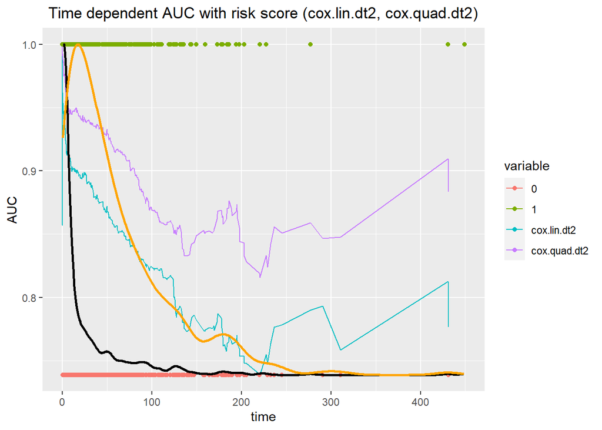

```r
dt2$censor1 <- ifelse(dt2$censor==1,
                    1,min(na.omit(ROC.risk.lin.dt2[["AUC"]])))
ggplot() +
  geom_line(data=res2, aes(x=time, y=value,
                            group=variable, color=variable)) +
  geom_point(data=dt2, aes(x=time, y=censor1, color=as.factor(censor))) +
  geom_line(data=data2_1, aes(x=time, y=density.adjusted),
            size=1, colour='black') +
  geom_line(data=data2_2, aes(x=time, y=density.adjusted),
            size=1, colour='orange') +
  scale_x_continuous(limits = c(min(dt2$time), max(dt2$time))) +
  ggtitle("Time dependent AUC with risk score (cox.lin.dt2, cox.quad.dt2)") +
  xlab("time") + ylab("AUC") +
  theme(plot.title = element_text(hjust = 0.5))
```

#### Mean value of Time dependent AUC (cox.lin.dt2, cox.quad.dt2)

```r
mean(ROC.risk.lin.dt2[["AUC"]],na.rm=TRUE)
```

```
## [1] 0.8945825
```

```r
mean(ROC.risk.quad.dt2[["AUC"]],na.rm=TRUE)
```

```
## [1] 0.9432075
```

#### Counting censored data

```r
dt2.censor <- dt2[dt2$censor==0,]
dt2.censor <- dt2.censor %>%
  mutate(n.cen=cut(dt2.censor$time,
                   breaks=seq(from=0,to=1000,by=50)))
table(dt2.censor$n.cen)
```

```
##
##      (0,50]    (50,100]   (100,150]   (150,200]   (200,250]   (250,300]
##         212          83          39          22           7           1
##   (300,350]   (350,400]   (400,450]   (450,500]   (500,550]   (550,600]
##           1           0           1           0           0           0
##   (600,650]   (650,700]   (700,750]   (750,800]   (800,850]   (850,900]
##           0           0           0           0           0           0
##   (900,950] (950,1e+03]
##           0           0
```

## Compare two results

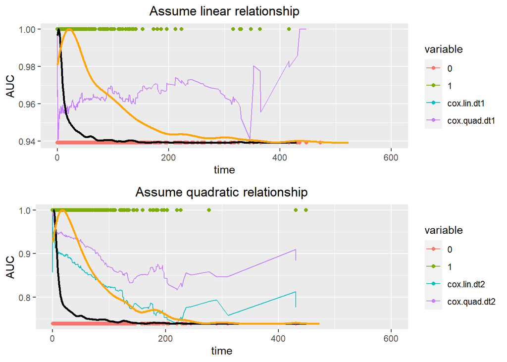

```r
a <- ggplot()

fig1 <- a +
  geom_line(data=res1, aes(x=time, y=value,
                            group=variable, color=variable)) +
  geom_point(data=dt1, aes(x=time, y=censor1, color=as.factor(censor))) +
  geom_line(data=data1_1, aes(x=time, y=density.adjusted),
            size=1, colour='black') +
  geom_line(data=data1_2, aes(x=time, y=density.adjusted),
            size=1, colour='orange') +
  scale_x_continuous(limits = c(0, 600)) +
  ggtitle("Assume linear relationship") +
  xlab("time") + ylab("AUC") +
  theme(plot.title = element_text(hjust = 0.5))

fig2 <- a +
  geom_line(data=res2, aes(x=time, y=value,
                            group=variable, color=variable)) +
  geom_point(data=dt2, aes(x=time, y=censor1, color=as.factor(censor))) +
  geom_line(data=data2_1, aes(x=time, y=density.adjusted),
            size=1, colour='black') +
  geom_line(data=data2_2, aes(x=time, y=density.adjusted),
            size=1, colour='orange') +
  scale_x_continuous(limits = c(0, 600)) +
  ggtitle("Assume quadratic relationship") +
  xlab("time") + ylab("AUC") +
  theme(plot.title = element_text(hjust = 0.5))

grid.arrange(fig1, fig2, nrow=2, ncol=1)
```

## simulation (repeat 100 times)

### Assume linear relationship

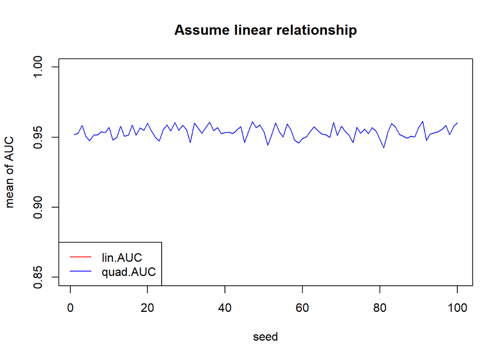

```r
seed <- c()
lin.AUC <- c()
quad.AUC <- c()

for (i in 1:100) {

  # Assume parametric basis distribution is Exponential distribution...
  lambda1 <- 0.01 # parameter for generate Y
  lambda2 <- 0.01 # parameter for generate C
  beta1 <- 3 # true coefficients
  Y <- c() # real survival time
  C <- c() # censoring time
  t <- c() # observed survival time
  censor <- c() # censoring indicator
  X <- c() # explanatory variable
  U1 <- c() # random variable from U(0,1) for generate Y
  U2 <- c() # random variable from U(0,1) for generate C
  X2 <- c() # X^2

  # Generate simulation data (Assume linear relationship)
  seed[i] <- i
  set.seed(i)
  for (j in 1:1000) {
    U1[j] <- runif(1)
    U2[j] <- runif(1)
    X[j] <- rnorm(1,mean=0,sd=1)
    X2[j] <- X[j]^2
    Y[j] <- -(1/lambda1)*log(U1[j])*exp(-beta1*X[j])
    C[j] <- -(1/lambda2)*log(U2[j])
    t[j] <- min(Y[j],C[j])
    censor[j] <- ifelse(Y[j]<=C[j],1,0)
  }
  dt1 <- data.frame(X=X, X2=X2, Y=Y, C=C, time=t, censor=censor)

  # Set linear model
  cox.lin.dt1 <- coxph(Surv(time,censor) ~ X, data=dt1)
  risk.lin.dt1 <- predict(object=cox.lin.dt1, newdata=dt1, type="risk")
  dt1$risk.lin.dt1 <- risk.lin.dt1
  ROC.risk.lin.dt1 <- timeROC(T=dt1$time,
                         delta=dt1$censor,marker=dt1$risk.lin.dt1,
                         cause=1,weighting="marginal",
                         times=dt1$time)

  # Set quadratic model
  cox.quad.dt1 <- coxph(Surv(time,censor) ~ X+X2, data=dt1)
  risk.quad.dt1 <- predict(object=cox.quad.dt1, newdata=dt1, type="risk")
  dt1$risk.quad.dt1 <- risk.quad.dt1
  ROC.risk.quad.dt1 <- timeROC(T=dt1$time,
                         delta=dt1$censor,marker=dt1$risk.quad.dt1,
                         cause=1,weighting="marginal",
                         times=dt1$time)

  # Calculate mean value of time dependent AUC
  lin.AUC[i] <- mean(ROC.risk.lin.dt1[["AUC"]],na.rm=TRUE)
  quad.AUC[i] <- mean(ROC.risk.quad.dt1[["AUC"]],na.rm=TRUE)

  # print(i)

}

dat1 <- data.frame(seed=seed, lin.AUC=lin.AUC, quad.AUC=quad.AUC)
plot(x=dat1$seed, y=dat1$lin.AUC, xlab="seed", ylab="mean of AUC",
     main="Assume linear relationship", type="l", col="red", ylim=c(0.85,1))
lines(x=dat1$seed, y=dat1$quad.AUC, type="l", col="blue")
legend("bottomleft",c("lin.AUC","quad.AUC"),col=c("red","blue"),lty=c(1,1))
```

### Assume quadratic relationship

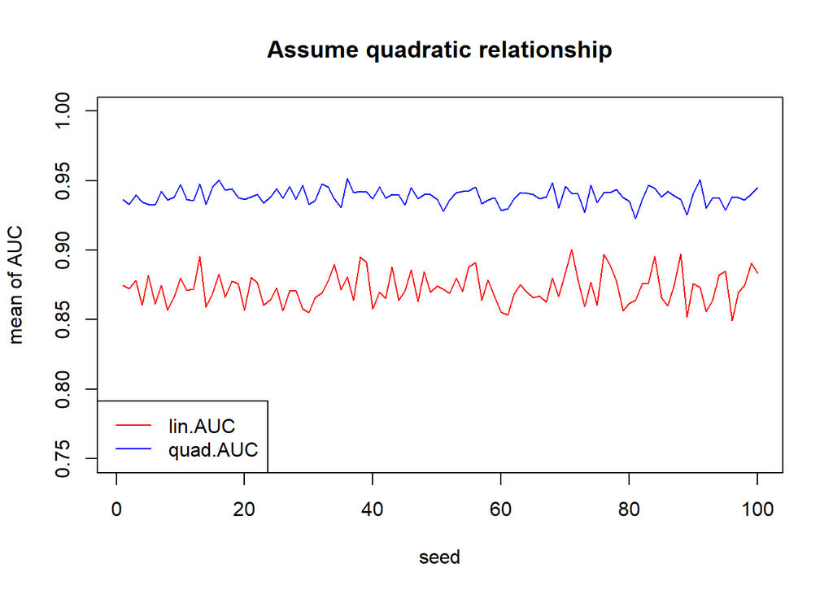

```r
seed <- c()
lin.AUC <- c()
quad.AUC <- c()

for (i in 1:100) {

  # Assume parametric basis distribution is Exponential distribution...
  lambda1 <- 0.01 # parameter for generate Y
  lambda2 <- 0.01 # parameter for generate C
  beta1 <- 3 ; beta2 <- 2 # true coefficients
  Y <- c() # real survival time
  C <- c() # censoring time
  t <- c() # observed survival time
  censor <- c() # censoring indicator
  X <- c() # explanatory variable
  U1 <- c() # random variable from U(0,1) for generate Y
  U2 <- c() # random variable from U(0,1) for generate C
  X2 <- c() # X^2

  # Generate simulation data (Assume quadratic relationship)
  seed[i] <- i
  set.seed(i)
  for (j in 1:1000) {
    U1[j] <- runif(1)
    U2[j] <- runif(1)
    X[j] <- rnorm(1,mean=0,sd=1)
    X2[j] <- X[j]^2
    Y[j] <- -(1/lambda1)*log(U1[j])*exp(-beta1*X[j]-beta2*X2[j])
    C[j] <- -(1/lambda2)*log(U2[j])
    t[j] <- min(Y[j],C[j])
    censor[j] <- ifelse(Y[j]<=C[j],1,0)
  }
  dt2 <- data.frame(X=X, X2=X2, Y=Y, C=C, time=t, censor=censor)

  # Set linear model
  cox.lin.dt2 <- coxph(Surv(time,censor) ~ X, data=dt2)
  risk.lin.dt2 <- predict(object=cox.lin.dt2, newdata=dt2, type="risk")
  dt2$risk.lin.dt2 <- risk.lin.dt2
  ROC.risk.lin.dt2 <- timeROC(T=dt2$time,
                         delta=dt2$censor,marker=dt2$risk.lin.dt2,
                         cause=1,weighting="marginal",
                         times=dt2$time)

  # Set quadratic model
  cox.quad.dt2 <- coxph(Surv(time,censor) ~ X+X2, data=dt2)
  risk.quad.dt2 <- predict(object=cox.quad.dt2, newdata=dt2, type="risk")
  dt2$risk.quad.dt2 <- risk.quad.dt2
  ROC.risk.quad.dt2 <- timeROC(T=dt2$time,
                         delta=dt2$censor,marker=dt2$risk.quad.dt2,
                         cause=1,weighting="marginal",
                         times=dt2$time)

  # Calculate mean value of time dependent AUC
  lin.AUC[i] <- mean(ROC.risk.lin.dt2[["AUC"]],na.rm=TRUE)
  quad.AUC[i] <- mean(ROC.risk.quad.dt2[["AUC"]],na.rm=TRUE)

  # print(i)
}

dat2 <- data.frame(seed=seed, lin.AUC=lin.AUC, quad.AUC=quad.AUC)
plot(x=dat2$seed, y=dat2$lin.AUC, xlab="seed", ylab="mean of AUC",
     main="Assume quadratic relationship", type="l", col="red", ylim=c(0.75,1))
lines(x=dat2$seed, y=dat2$quad.AUC, type="l", col="blue")
legend("bottomleft",c("lin.AUC","quad.AUC"),col=c("red","blue"),lty=c(1,1))
```

# Set other distributions

## Background

`-` real survival time $Y$ : Exponential distribution `-` censoring time $C$ : Uniform distribution

- $h(t|x)=h_{0}(t)exp(f(x))$
- $H(t|x)=\int_{0}^{t} h(s|x)ds= \int_{0}^{t} h_{0}(s)exp(f(x))ds=H_{0}(t)exp(f(x))$
- $h(t|x)=\frac {f(t|x)}{S(t|x)}= -\frac {d}{dt} log[S(t|x)]$
- $log[S(t|x)]= -\int_{0}^{t} h(s|x)ds= -H(t|x)= -H_{0}(t)exp(f(x))$
- $S(t|x)=exp[-H_{0}(t)exp(f(x))]$
- In general,…
- $F(t|x)=1-exp[-H_{0}(t) exp(f(x))]$
- -> $F^{-1}(t|x)=H_{0}^{-1}[-log(1-t) exp(-f(x))]$
- By Inverse Transform Sampling, suppose that $U_{1}, U_{2} \overset{i.i.d}{\sim}\ U(0,1)$, then we can generate real survival time $Y$ from Cox Regression Model using this equation.
- $Y=H_{Y0}^{-1}[-log(U_{1})exp(-f(x))]$
- And by assuming non-informative censoring, we can generate censoring time $C$ like this equation. (Set $Y$ and $C$ are independent each other.)
- $C=H_{C0}^{-1}[-log(U_{2})]$
- And set censoring indicator $\delta=I(Y \leq C)$ and observed survival time $T=min(Y,C)$
- $H_{Y0}(t)$ : Basis cumulative hazard function of real survival time $Y$
- $H_{C0}(t)$ : Basis cumulative hazard function of censoring time $C$
- When parametric basis distribution of real survival time $Y$ is Exponential distribution and parametric basis distribution of censoring time $C$ is Uniform distribution ($Y$ and $C$ are independent each other), then ~
- $Y$ : $f_{Y0}(t)=\lambda e^{-\lambda t}, t>0$ -> $S_{Y0}(t)=e^{-\lambda t}$ -> $h_{Y0}(t)=\lambda$
- $C$ : $f_{C0}(t)=\frac {1}{\lambda}, 0<t<\lambda$ -> $S_{C0}(t)=1-\frac {t}{\lambda}$ -> $h_{C0}(t)=\frac {1}{\lambda -t}$
- $\therefore Y=-\frac{1}{\lambda_{1}} log(U_{1}) exp(-f(x))$, $C=\lambda_{2}(1-U_{2})$

# Generating simulation data

## Assume linear relationship

```r
# Assume parametric basis distribution is Exponential distribution...
lambda1 <- 0.001 # parameter for generate Y
lambda2 <- 1.5/lambda1 # parameter for generate C
beta1 <- 3 # true coefficients
Y <- c() # real survival time
C <- c() # censoring time
t <- c() # observed survival time
censor <- c() # censoring indicator
X <- c() # explanatory variable
U1 <- c() # random variable from U(0,1) for generate Y
U2 <- c() # random variable from U(0,1) for generate C
X2 <- c() # X^2

for (i in 1:1000) {
  U1[i] <- runif(1)
  U2[i] <- runif(1)
  # X[i] <- runif(1,min=0,max=10)
  X[i] <- rnorm(1,mean=0,sd=1)
  X2[i] <- X[i]^2
  Y[i] <- -(1/lambda1)*log(U1[i])*exp(-beta1*X[i])
  C[i] <- (lambda2)*(1-U2[i])
  t[i] <- min(Y[i],C[i])
  censor[i] <- ifelse(Y[i]<=C[i],1,0)
}

mean(1-censor) # censoring rate
```

```
## [1] 0.513
```

```r
dt3 <- data.frame(X=X, X2=X2, Y=Y, C=C, time=t, censor=censor)
head(dt3,20)
```

```
##              X          X2            Y         C       time censor
## 1  -0.22974319 0.052781932 1.850192e+02  972.6157  185.01917      1
## 2  -0.62730903 0.393516613 2.087908e+04 1318.1140 1318.11395      0
## 3  -1.33757722 1.789112819 4.998618e+04 1064.2675 1064.26745      0
## 4  -0.55237209 0.305114920 2.713483e+03  827.8251  827.82507      0
## 5   0.14826603 0.021982815 1.280330e+03  868.3171  868.31709      0
## 6  -1.01110909 1.022341586 2.125637e+03  473.3314  473.33140      0
## 7  -0.82717384 0.684216566 3.015893e+04  359.6397  359.63974      0
## 8  -0.11204886 0.012554947 1.665521e+03 1274.2556 1274.25563      0
## 9   0.35035553 0.122749000 7.501473e+02  825.1716  750.14733      1
## 10 -0.77985061 0.608166970 3.861652e+03  402.2404  402.24040      0
## 11 -1.68586337 2.842135301 2.700681e+05  335.3102  335.31022      0
## 12 -0.19549731 0.038219198 2.839368e+02  612.3361  283.93681      1
## 13 -0.06422923 0.004125394 1.077688e+03  240.1984  240.19835      0
## 14 -0.61945799 0.383728196 3.338613e+03 1498.8414 1498.84140      0
## 15  0.29187426 0.085190582 3.244262e+02 1077.0634  324.42621      1
## 16  0.06130790 0.003758658 9.727688e+02  348.1305  348.13051      0
## 17 -2.89899964 8.404198900 8.197670e+06 1062.5624 1062.56242      0
## 18  0.49882343 0.248824811 3.082874e+01 1128.3432   30.82874      1
## 19 -1.07926902 1.164821613 1.374990e+04 1421.2297 1421.22971      0
## 20  0.81280352 0.660649559 1.126824e+02 1263.1219  112.68238      1
```

```r
# dt3[c(order(dt3$time)),]$censor
```

### Time dependent AUC

### True model

- $h(t|x)=h _{0} (t)exp[f(x)]$
- $f(x)=\beta_{1} x$
- True coefficients : $\beta_{1}=3$

### Set linear model

- $h(t|x)=h _{0} (t)exp[f(x)]$
- $f(x)=\beta_{1}x$

```r
cox.lin.dt3 <- coxph(Surv(time,censor) ~ X, data=dt3)
summary(cox.lin.dt3)
```

```
## Call:
## coxph(formula = Surv(time, censor) ~ X, data = dt3)
##
##   n= 1000, number of events= 487
##
##      coef exp(coef) se(coef)     z Pr(>|z|)
## X  3.0225   20.5419   0.1056 28.63   <2e-16 ***
## ---
## Signif. codes:  0 '***' 0.001 '**' 0.01 '*' 0.05 '.' 0.1 ' ' 1
##
##   exp(coef) exp(-coef) lower .95 upper .95
## X     20.54    0.04868      16.7     25.26
##
## Concordance= 0.899  (se = 0.006 )
## Likelihood ratio test= 1302  on 1 df,   p=<2e-16
## Wald test            = 819.6  on 1 df,   p=<2e-16
## Score (logrank) test = 936.6  on 1 df,   p=<2e-16
```

```r
risk.lin.dt3 <- predict(object=cox.lin.dt3, newdata=dt3, type="risk") # risk score
dt3$risk.lin.dt3 <- risk.lin.dt3
ROC.risk.lin.dt3 <- timeROC(T=dt3$time,
                         delta=dt3$censor,marker=dt3$risk.lin.dt3,
                         cause=1,weighting="marginal",
                         times=dt3$time)
ROC.risk.lin.dt3
```

```
## Time-dependent-Roc curve estimated using IPCW  (n=1000, without competing risks).
##                      Cases Survivors Censored AUC (%)
## t=0.0179979018132785     0       999        1      NA
## t=48.7263043199668     216       749       35   94.75
## t=249.370876117609     376       500      124   94.89
## t=704.571651178412     462       250      288   96.14
## t=1499.34527033474     487         0      513      NA
##
## Method used for estimating IPCW:marginal
##
## Total computation time : 0.31  secs.
```

### Set quadratic model

- $h(t|x)=h _{0} (t)exp[f(x)]$
- $f(x)=\beta_{1}x+\beta_{2}x^2$

```r
cox.quad.dt3 <- coxph(Surv(time,censor) ~ X+X2, data=dt3)
summary(cox.quad.dt3)
```

```
## Call:
## coxph(formula = Surv(time, censor) ~ X + X2, data = dt3)
##
##   n= 1000, number of events= 487
##
##        coef exp(coef) se(coef)      z Pr(>|z|)
## X   2.94009  18.91763  0.14448 20.350   <2e-16 ***
## X2  0.06266   1.06466  0.07740  0.809    0.418
## ---
## Signif. codes:  0 '***' 0.001 '**' 0.01 '*' 0.05 '.' 0.1 ' ' 1
##
##    exp(coef) exp(-coef) lower .95 upper .95
## X     18.918    0.05286   14.2524    25.110
## X2     1.065    0.93926    0.9148     1.239
##
## Concordance= 0.899  (se = 0.006 )
## Likelihood ratio test= 1303  on 2 df,   p=<2e-16
## Wald test            = 840.5  on 2 df,   p=<2e-16
## Score (logrank) test = 1841  on 2 df,   p=<2e-16
```

```r
risk.quad.dt3 <- predict(object=cox.quad.dt3, newdata=dt3, type="risk") # risk score
dt3$risk.quad.dt3 <- risk.quad.dt3
ROC.risk.quad.dt3 <- timeROC(T=dt3$time,
                         delta=dt3$censor,marker=dt3$risk.quad.dt3,
                         cause=1,weighting="marginal",
                         times=dt3$time)
ROC.risk.quad.dt3
```

```
## Time-dependent-Roc curve estimated using IPCW  (n=1000, without competing risks).
##                      Cases Survivors Censored AUC (%)
## t=0.0179979018132785     0       999        1      NA
## t=48.7263043199668     216       749       35   94.75
## t=249.370876117609     376       500      124   94.89
## t=704.571651178412     462       250      288   96.14
## t=1499.34527033474     487         0      513      NA
##
## Method used for estimating IPCW:marginal
##
## Total computation time : 0.35  secs.
```

#### Make AUC data

```r
# uncensored
uncensored.density3 <- density(dt3$time[dt3$censor==1])
data3_1 <- data.frame(time=uncensored.density3[["x"]],
                    density=uncensored.density3[["y"]])
data3_1$density.adjusted <- (max(na.omit(ROC.risk.lin.dt3[["AUC"]]))-min(na.omit(ROC.risk.lin.dt3[["AUC"]])))*(uncensored.density3[["y"]]-min(uncensored.density3[["y"]]))/(max(uncensored.density3[["y"]])-min(uncensored.density3[["y"]]))+min(na.omit(ROC.risk.lin.dt3[["AUC"]]))

# censored
censored.density3 <- density(dt3$time[dt3$censor==0])
data3_2 <- data.frame(time=censored.density3[["x"]],
                    density=censored.density3[["y"]])
data3_2$density.adjusted <- (max(na.omit(ROC.risk.lin.dt3[["AUC"]]))-min(na.omit(ROC.risk.lin.dt3[["AUC"]])))*(censored.density3[["y"]]-min(censored.density3[["y"]]))/(max(censored.density3[["y"]])-min(censored.density3[["y"]]))+min(na.omit(ROC.risk.lin.dt3[["AUC"]]))

res3 <- data.frame(time=ROC.risk.lin.dt3[["times"]],
                    cox.lin.dt3=ROC.risk.lin.dt3[["AUC"]],
                    cox.quad.dt3=ROC.risk.quad.dt3[["AUC"]])
res3 <- melt(data = res3,
                   id.vars = "time",
                   measure.vars = c("cox.lin.dt3","cox.quad.dt3"))
```

#### Time dependent AUC plot with ggplot2 (cox.lin.dt3, cox.quad.dt3)

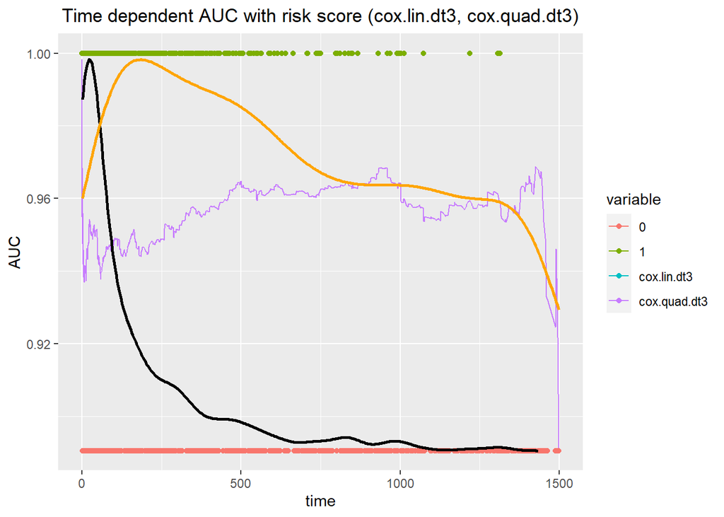

```r
dt3$censor1 <- ifelse(dt3$censor==1,
                    1,min(na.omit(ROC.risk.lin.dt3[["AUC"]])))
ggplot() +
  geom_line(data=res3, aes(x=time, y=value,
                            group=variable, color=variable)) +
  geom_point(data=dt3, aes(x=time, y=censor1, color=as.factor(censor))) +
  geom_line(data=data3_1, aes(x=time, y=density.adjusted),
            size=1, colour='black') +
  geom_line(data=data3_2, aes(x=time, y=density.adjusted),
            size=1, colour='orange') +
  scale_x_continuous(limits = c(min(dt3$time), max(dt3$time))) +
  ggtitle("Time dependent AUC with risk score (cox.lin.dt3, cox.quad.dt3)") +
  xlab("time") + ylab("AUC") +
  theme(plot.title = element_text(hjust = 0.5))
```

#### Mean value of Time dependent AUC (cox.lin.dt3, cox.quad.dt3)

```r
mean(ROC.risk.lin.dt3[["AUC"]],na.rm=TRUE)
```

```
## [1] 0.9540211
```

```r
mean(ROC.risk.quad.dt3[["AUC"]],na.rm=TRUE)
```

```
## [1] 0.9540211
```

#### Counting censored data

```r
dt3.censor <- dt3[dt3$censor==0,]
dt3.censor <- dt3.censor %>%
  mutate(n.cen=cut(dt3.censor$time,
                   breaks=seq(from=0,to=1500,by=50)))
table(dt3.censor$n.cen)
```

```
##
##             (0,50]           (50,100]          (100,150]          (150,200]
##                 35                 25                 19                 22
##          (200,250]          (250,300]          (300,350]          (350,400]
##                 23                 20                 13                 25
##          (400,450]          (450,500]          (500,550]          (550,600]
##                 16                 20                 20                 17
##          (600,650]          (650,700]          (700,750]          (750,800]
##                 19                 12                 17                 13
##          (800,850]          (850,900]          (900,950]        (950,1e+03]
##                 13                 15                 14                 12
##   (1e+03,1.05e+03] (1.05e+03,1.1e+03] (1.1e+03,1.15e+03] (1.15e+03,1.2e+03]
##                 17                 14                 17                  9
## (1.2e+03,1.25e+03] (1.25e+03,1.3e+03] (1.3e+03,1.35e+03] (1.35e+03,1.4e+03]
##                 15                 10                 14                 16
## (1.4e+03,1.45e+03] (1.45e+03,1.5e+03]
##                 21                 10
```

## Assume quadratic relationship

```r
# Assume parametric basis distribution is Exponential distribution...
lambda1 <- 0.001 # parameter for generate Y
lambda2 <- 1.5/lambda1 # parameter for generate C
beta1 <- 3 ; beta2 <- 2 # true coefficients
Y <- c() # real survival time
C <- c() # censoring time
t <- c() # observed survival time
censor <- c() # censoring indicator
X <- c() # explanatory variable
U1 <- c() # random variable from U(0,1) for generate Y
U2 <- c() # random variable from U(0,1) for generate C
X2 <- c() # X^2

for (i in 1:1000) {
  U1[i] <- runif(1)
  U2[i] <- runif(1)
  # X[i] <- runif(1,min=0,max=10)
  X[i] <- rnorm(1,mean=0,sd=1)
  X2[i] <- X[i]^2
  Y[i] <- -(1/lambda1)*log(U1[i])*exp(-beta1*X[i]-beta2*X2[i])
  C[i] <- (lambda2)*(1-U2[i])
  t[i] <- min(Y[i],C[i])
  censor[i] <- ifelse(Y[i]<=C[i],1,0)
}

mean(1-censor) # censoring rate
```

```
## [1] 0.371
```

```r
dt4 <- data.frame(X=X, X2=X2, Y=Y, C=C, time=t, censor=censor)
head(dt4,20)
```

```
##              X         X2            Y          C         time censor
## 1  -0.27343947 0.07476914 1.346150e+02  791.84035 1.346150e+02      1
## 2  -0.12918348 0.01668837 1.716414e+03 1298.08868 1.298089e+03      0
## 3   0.27666677 0.07654450 4.222725e+02  538.01293 4.222725e+02      1
## 4  -0.44711210 0.19990923 1.752015e+03  480.83325 4.808332e+02      0
## 5  -1.65091214 2.72551090 3.460388e+02 1049.88234 3.460388e+02      1
## 6  -0.13803023 0.01905234 3.870989e+03  766.96896 7.669690e+02      0
## 7   0.61056765 0.37279286 1.107081e+02  414.59790 1.107081e+02      1
## 8   0.12194705 0.01487108 1.401308e+02   11.91472 1.191472e+01      0
## 9   1.77493227 3.15038456 9.578273e-03  280.57536 9.578273e-03      1
## 10  0.85018400 0.72281283 2.376242e+01 1083.84309 2.376242e+01      1
## 11 -0.48260789 0.23291038 3.050495e+03  466.20792 4.662079e+02      0
## 12 -0.21923586 0.04806436 8.242035e+02  895.87346 8.242035e+02      1
## 13  0.70004629 0.49006481 6.308738e+00   98.09917 6.308738e+00      1
## 14  0.09526515 0.00907545 8.424180e+02  795.37991 7.953799e+02      0
## 15  0.45666360 0.20854164 2.829859e+01 1439.59478 2.829859e+01      1
## 16  0.23617747 0.05577980 1.819241e+02 1155.71189 1.819241e+02      1
## 17 -0.25348100 0.06425262 4.061848e+03  920.92319 9.209232e+02      0
## 18 -0.13296078 0.01767857 7.514209e+02  120.15538 1.201554e+02      0
## 19 -1.30886723 1.71313342 2.529617e+02  798.72494 2.529617e+02      1
## 20  0.17711800 0.03137079 1.421432e+02  335.22152 1.421432e+02      1
```

```r
# dt4[c(order(dt4$time)),]$censor
```

### Set linear model

- $h(t|x)=h _{0} (t)exp[f(x)]$
- $f(x)=\beta_{1}x$

```r
cox.lin.dt4 <- coxph(Surv(time,censor) ~ X, data=dt4)
summary(cox.lin.dt4)
```

```
## Call:
## coxph(formula = Surv(time, censor) ~ X, data = dt4)
##
##   n= 1000, number of events= 629
##
##      coef exp(coef) se(coef)     z Pr(>|z|)
## X 2.23826   9.37699  0.09378 23.87   <2e-16 ***
## ---
## Signif. codes:  0 '***' 0.001 '**' 0.01 '*' 0.05 '.' 0.1 ' ' 1
##
##   exp(coef) exp(-coef) lower .95 upper .95
## X     9.377     0.1066     7.803     11.27
##
## Concordance= 0.827  (se = 0.011 )
## Likelihood ratio test= 809  on 1 df,   p=<2e-16
## Wald test            = 569.7  on 1 df,   p=<2e-16
## Score (logrank) test = 651.1  on 1 df,   p=<2e-16
```

```r
risk.lin.dt4 <- predict(object=cox.lin.dt4, newdata=dt4, type="risk") # risk score
dt4$risk.lin.dt4 <- risk.lin.dt4
ROC.risk.lin.dt4 <- timeROC(T=dt4$time,
                         delta=dt4$censor,marker=dt4$risk.lin.dt4,
                         cause=1,weighting="marginal",
                         times=dt4$time)
ROC.risk.lin.dt4
```

```
## Time-dependent-Roc curve estimated using IPCW  (n=1000, without competing risks).
##                        Cases Survivors Censored AUC (%)
## t=4.82111368596028e-09     0       999        1      NA
## t=18.4576665069284       240       749       11   93.83
## t=166.006021374314       421       500       79   87.30
## t=554.122932837345       559       250      191   82.93
## t=1488.86564781424       629         0      371      NA
##
## Method used for estimating IPCW:marginal
##
## Total computation time : 0.44  secs.
```

### Set quadratic model

- $h(t|x)=h _{0} (t)exp[f(x)]$
- $f(x)=\beta_{1}x+\beta_{2}x^2$

```r
cox.quad.dt4 <- coxph(Surv(time,censor) ~ X+X2, data=dt4)
summary(cox.quad.dt4)
```

```
## Call:
## coxph(formula = Surv(time, censor) ~ X + X2, data = dt4)
##
##   n= 1000, number of events= 629
##
##        coef exp(coef) se(coef)     z Pr(>|z|)
## X   2.85976  17.45733  0.08874 32.23   <2e-16 ***
## X2  1.86565   6.46016  0.06245 29.88   <2e-16 ***
## ---
## Signif. codes:  0 '***' 0.001 '**' 0.01 '*' 0.05 '.' 0.1 ' ' 1
##
##    exp(coef) exp(-coef) lower .95 upper .95
## X      17.46    0.05728    14.670    20.774
## X2      6.46    0.15479     5.716     7.301
##
## Concordance= 0.88  (se = 0.007 )
## Likelihood ratio test= 1685  on 2 df,   p=<2e-16
## Wald test            = 1088  on 2 df,   p=<2e-16
## Score (logrank) test = 2573  on 2 df,   p=<2e-16
```

```r
risk.quad.dt4 <- predict(object=cox.quad.dt4, newdata=dt4, type="risk") # risk score
dt4$risk.quad.dt4 <- risk.quad.dt4
ROC.risk.quad.dt4 <- timeROC(T=dt4$time,
                         delta=dt4$censor,marker=dt4$risk.quad.dt4,
                         cause=1,weighting="marginal",
                         times=dt4$time)
ROC.risk.quad.dt4
```

```
## Time-dependent-Roc curve estimated using IPCW  (n=1000, without competing risks).
##                        Cases Survivors Censored AUC (%)
## t=4.82111368596028e-09     0       999        1      NA
## t=18.4576665069284       240       749       11   97.53
## t=166.006021374314       421       500       79   93.16
## t=554.122932837345       559       250      191   90.26
## t=1488.86564781424       629         0      371      NA
##
## Method used for estimating IPCW:marginal
##
## Total computation time : 0.3  secs.
```

#### Make AUC data

```r
# uncensored
uncensored.density4 <- density(dt4$time[dt4$censor==1])
data4_1 <- data.frame(time=uncensored.density4[["x"]],
                    density=uncensored.density4[["y"]])
data4_1$density.adjusted <- (max(na.omit(ROC.risk.lin.dt4[["AUC"]]))-min(na.omit(ROC.risk.lin.dt4[["AUC"]])))*(uncensored.density4[["y"]]-min(uncensored.density4[["y"]]))/(max(uncensored.density4[["y"]])-min(uncensored.density4[["y"]]))+min(na.omit(ROC.risk.lin.dt4[["AUC"]]))

# censored
censored.density4 <- density(dt4$time[dt4$censor==0])
data4_2 <- data.frame(time=censored.density4[["x"]],
                    density=censored.density4[["y"]])
data4_2$density.adjusted <- (max(na.omit(ROC.risk.lin.dt4[["AUC"]]))-min(na.omit(ROC.risk.lin.dt4[["AUC"]])))*(censored.density4[["y"]]-min(censored.density4[["y"]]))/(max(censored.density4[["y"]])-min(censored.density4[["y"]]))+min(na.omit(ROC.risk.lin.dt4[["AUC"]]))

res4 <- data.frame(time=ROC.risk.lin.dt4[["times"]],
                    cox.lin.dt4=ROC.risk.lin.dt4[["AUC"]],
                    cox.quad.dt4=ROC.risk.quad.dt4[["AUC"]])
res4 <- melt(data = res4,
                   id.vars = "time",
                   measure.vars = c("cox.lin.dt4","cox.quad.dt4"))
```

#### Time dependent AUC plot with ggplot2 (cox.lin.dt4, cox.quad.dt4)

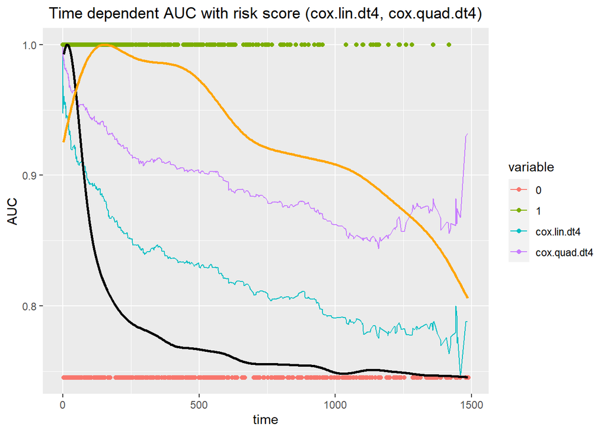

```r
dt4$censor1 <- ifelse(dt4$censor==1,
                    1,min(na.omit(ROC.risk.lin.dt4[["AUC"]])))
ggplot() +
  geom_line(data=res4, aes(x=time, y=value,
                            group=variable, color=variable)) +
  geom_point(data=dt4, aes(x=time, y=censor1, color=as.factor(censor))) +
  geom_line(data=data4_1, aes(x=time, y=density.adjusted),
            size=1, colour='black') +
  geom_line(data=data4_2, aes(x=time, y=density.adjusted),
            size=1, colour='orange') +
  scale_x_continuous(limits = c(min(dt4$time), max(dt4$time))) +
  ggtitle("Time dependent AUC with risk score (cox.lin.dt4, cox.quad.dt4)") +
  xlab("time") + ylab("AUC") +
  theme(plot.title = element_text(hjust = 0.5))
```

#### Mean value of Time dependent AUC (cox.lin.dt4, cox.quad.dt4)

```r
mean(ROC.risk.lin.dt4[["AUC"]],na.rm=TRUE)
```

```
## [1] 0.8780786
```

```r
mean(ROC.risk.quad.dt4[["AUC"]],na.rm=TRUE)
```

```
## [1] 0.9324629
```

#### Counting censored data

```r
dt4.censor <- dt4[dt4$censor==0,]
dt4.censor <- dt4.censor %>%
  mutate(n.cen=cut(dt4.censor$time,
                   breaks=seq(from=0,to=1500,by=50)))
table(dt4.censor$n.cen)
```

```
##
##             (0,50]           (50,100]          (100,150]          (150,200]
##                 30                 24                 20                  8
##          (200,250]          (250,300]          (300,350]          (350,400]
##                 15                 16                 15                 15
##          (400,450]          (450,500]          (500,550]          (550,600]
##                 15                 15                 17                 15
##          (600,650]          (650,700]          (700,750]          (750,800]
##                  8                  6                 14                 15
##          (800,850]          (850,900]          (900,950]        (950,1e+03]
##                 12                  7                 10                 11
##   (1e+03,1.05e+03] (1.05e+03,1.1e+03] (1.1e+03,1.15e+03] (1.15e+03,1.2e+03]
##                 10                 11                 11                  8
## (1.2e+03,1.25e+03] (1.25e+03,1.3e+03] (1.3e+03,1.35e+03] (1.35e+03,1.4e+03]
##                  9                  6                  7                  8
## (1.4e+03,1.45e+03] (1.45e+03,1.5e+03]
##                  9                  4
```

## Compare two results

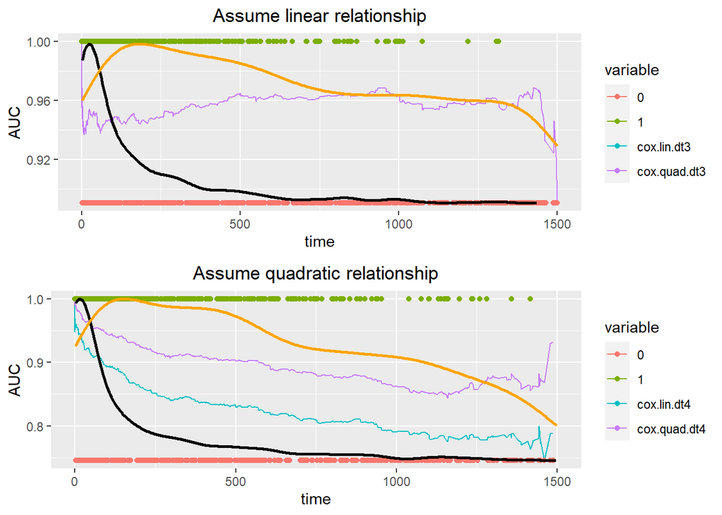

```r
a <- ggplot()

fig1 <- a +
  geom_line(data=res3, aes(x=time, y=value,
                            group=variable, color=variable)) +
  geom_point(data=dt3, aes(x=time, y=censor1, color=as.factor(censor))) +
  geom_line(data=data3_1, aes(x=time, y=density.adjusted),
            size=1, colour='black') +
  geom_line(data=data3_2, aes(x=time, y=density.adjusted),
            size=1, colour='orange') +
  scale_x_continuous(limits = c(0, 1500)) +
  ggtitle("Assume linear relationship") +
  xlab("time") + ylab("AUC") +
  theme(plot.title = element_text(hjust = 0.5))

fig2 <- a +
  geom_line(data=res4, aes(x=time, y=value,
                            group=variable, color=variable)) +
  geom_point(data=dt4, aes(x=time, y=censor1, color=as.factor(censor))) +
  geom_line(data=data4_1, aes(x=time, y=density.adjusted),
            size=1, colour='black') +
  geom_line(data=data4_2, aes(x=time, y=density.adjusted),
            size=1, colour='orange') +
  scale_x_continuous(limits = c(0, 1500)) +
  ggtitle("Assume quadratic relationship") +
  xlab("time") + ylab("AUC") +
  theme(plot.title = element_text(hjust = 0.5))

grid.arrange(fig1, fig2, nrow=2, ncol=1)
```

## simulation (repeat 100 times)

### Assume linear relationship

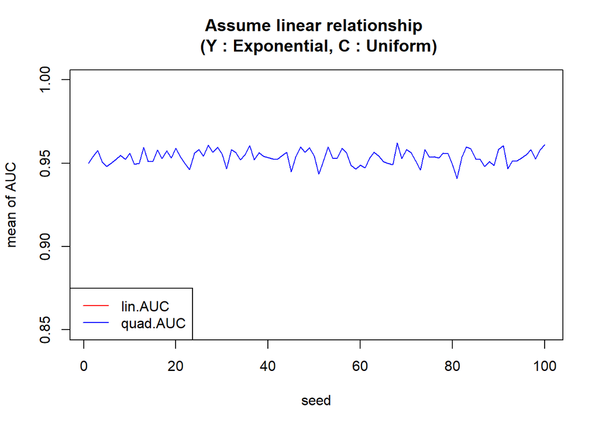

```r
seed <- c()
lin.AUC <- c()
quad.AUC <- c()

for (i in 1:100) {

  # Assume parametric basis distribution is Exponential distribution...
  lambda1 <- 0.001 # parameter for generate Y
  lambda2 <- 1.5/lambda1 # parameter for generate C
  beta1 <- 3 # true coefficients
  Y <- c() # real survival time
  C <- c() # censoring time
  t <- c() # observed survival time
  censor <- c() # censoring indicator
  X <- c() # explanatory variable
  U1 <- c() # random variable from U(0,1) for generate Y
  U2 <- c() # random variable from U(0,1) for generate C
  X2 <- c() # X^2

  # Generate simulation data (Assume linear relationship)
  seed[i] <- i
  set.seed(i)
  for (j in 1:1000) {
    U1[j] <- runif(1)
    U2[j] <- runif(1)
    X[j] <- rnorm(1,mean=0,sd=1)
    X2[j] <- X[j]^2
    Y[j] <- -(1/lambda1)*log(U1[j])*exp(-beta1*X[j])
    C[j] <- (lambda2)*(1-U2[j])
    t[j] <- min(Y[j],C[j])
    censor[j] <- ifelse(Y[j]<=C[j],1,0)
  }
  dt3 <- data.frame(X=X, X2=X2, Y=Y, C=C, time=t, censor=censor)

  # Set linear model
  cox.lin.dt3 <- coxph(Surv(time,censor) ~ X, data=dt3)
  risk.lin.dt3 <- predict(object=cox.lin.dt3, newdata=dt3, type="risk")
  dt3$risk.lin.dt3 <- risk.lin.dt3
  ROC.risk.lin.dt3 <- timeROC(T=dt3$time,
                         delta=dt3$censor,marker=dt3$risk.lin.dt3,
                         cause=1,weighting="marginal",
                         times=dt3$time)

  # Set quadratic model
  cox.quad.dt3 <- coxph(Surv(time,censor) ~ X+X2, data=dt3)
  risk.quad.dt3 <- predict(object=cox.quad.dt3, newdata=dt3, type="risk")
  dt3$risk.quad.dt3 <- risk.quad.dt3
  ROC.risk.quad.dt3 <- timeROC(T=dt3$time,
                         delta=dt3$censor,marker=dt3$risk.quad.dt3,
                         cause=1,weighting="marginal",
                         times=dt3$time)

  # Calculate mean value of time dependent AUC
  lin.AUC[i] <- mean(ROC.risk.lin.dt3[["AUC"]],na.rm=TRUE)
  quad.AUC[i] <- mean(ROC.risk.quad.dt3[["AUC"]],na.rm=TRUE)

  # print(i)

}

dat3 <- data.frame(seed=seed, lin.AUC=lin.AUC, quad.AUC=quad.AUC)
plot(x=dat3$seed, y=dat3$lin.AUC, xlab="seed", ylab="mean of AUC",
     main="Assume linear relationship \n (Y : Exponential, C : Uniform)", type="l", col="red", ylim=c(0.85,1))
lines(x=dat3$seed, y=dat3$quad.AUC, type="l", col="blue")
legend("bottomleft",c("lin.AUC","quad.AUC"),col=c("red","blue"),lty=c(1,1))
```

### Assume quadratic relationship

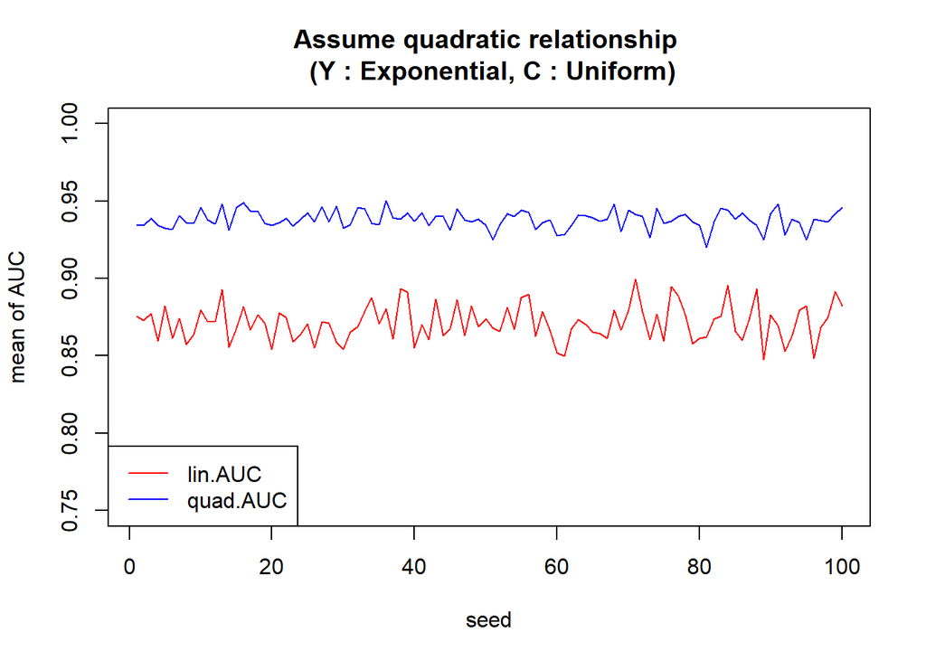

```r
seed <- c()
lin.AUC <- c()
quad.AUC <- c()

for (i in 1:100) {

  # Assume parametric basis distribution is Exponential distribution...
  lambda1 <- 0.001 # parameter for generate Y
  lambda2 <- 1.5/lambda1 # parameter for generate C
  beta1 <- 3 ; beta2 <- 2 # true coefficients
  Y <- c() # real survival time
  C <- c() # censoring time
  t <- c() # observed survival time
  censor <- c() # censoring indicator
  X <- c() # explanatory variable
  U1 <- c() # random variable from U(0,1) for generate Y
  U2 <- c() # random variable from U(0,1) for generate C
  X2 <- c() # X^2

  # Generate simulation data (Assume quadratic relationship)
  seed[i] <- i
  set.seed(i)
  for (j in 1:1000) {
    U1[j] <- runif(1)
    U2[j] <- runif(1)
    X[j] <- rnorm(1,mean=0,sd=1)
    X2[j] <- X[j]^2
    Y[j] <- -(1/lambda1)*log(U1[j])*exp(-beta1*X[j]-beta2*X2[j])
    C[j] <- (lambda2)*(1-U2[j])
    t[j] <- min(Y[j],C[j])
    censor[j] <- ifelse(Y[j]<=C[j],1,0)
  }
  dt4 <- data.frame(X=X, X2=X2, Y=Y, C=C, time=t, censor=censor)

  # Set linear model
  cox.lin.dt4 <- coxph(Surv(time,censor) ~ X, data=dt4)
  risk.lin.dt4 <- predict(object=cox.lin.dt4, newdata=dt4, type="risk")
  dt4$risk.lin.dt4 <- risk.lin.dt4
  ROC.risk.lin.dt4 <- timeROC(T=dt4$time,
                         delta=dt4$censor,marker=dt4$risk.lin.dt4,
                         cause=1,weighting="marginal",
                         times=dt4$time)

  # Set quadratic model
  cox.quad.dt4 <- coxph(Surv(time,censor) ~ X+X2, data=dt4)
  risk.quad.dt4 <- predict(object=cox.quad.dt4, newdata=dt4, type="risk")
  dt4$risk.quad.dt4 <- risk.quad.dt4
  ROC.risk.quad.dt4 <- timeROC(T=dt4$time,
                         delta=dt4$censor,marker=dt4$risk.quad.dt4,
                         cause=1,weighting="marginal",
                         times=dt4$time)

  # Calculate mean value of time dependent AUC
  lin.AUC[i] <- mean(ROC.risk.lin.dt4[["AUC"]],na.rm=TRUE)
  quad.AUC[i] <- mean(ROC.risk.quad.dt4[["AUC"]],na.rm=TRUE)

  # print(i)

}

dat4 <- data.frame(seed=seed, lin.AUC=lin.AUC, quad.AUC=quad.AUC)
plot(x=dat4$seed, y=dat4$lin.AUC, xlab="seed", ylab="mean of AUC",
     main="Assume quadratic relationship \n (Y : Exponential, C : Uniform)", type="l", col="red", ylim=c(0.75,1))
lines(x=dat4$seed, y=dat4$quad.AUC, type="l", col="blue")
legend("bottomleft",c("lin.AUC","quad.AUC"),col=c("red","blue"),lty=c(1,1))
```